# ISRNM Global prevalence of PEW: Supplemental Information

(August 13, 2018)

(R-execution that created this file: Mon Aug 13 16:27:05 2018.)

Supplemental information to

**Global prevalence of protein-energy wasting (PEW) in kidney disease: a meta-analysis of contemporary observational studies from the International Society of Renal Nutrition and Metabolism (ISRNM)**

by

Juan J Carrero, Fridtjof Thomas, Kristóf Nagy, Fatiu Arogundade, Carla M Avesani, Maria Chan, Michal Chmielewski, Antonio C Cordeiro, Angeles Espinosa-Cuevas, Enrico Fiaccadori, Fitsum Guebre-Egziabher, Rosa K Hand, Adriana M Hung, Talat A Ikizler, Lina R Johansson, Kamyar Kalantar-Zadeh, Tilakavati Karupaiah, Bengt Lindholm, Peter Marckmann, Denise Mafra, Rulan S Parekh, Jongha Park, Sharon Russo, Anita Saxena, Siren Sezer, Daniel Teta, Pieter M Ter Wee, Cecile Verseput, Angela YM Wang, Hong Xu, Lu Yimin, Miklos Z Molnar, Csaba P Kovesdy

> This file is intended to be viewed as **html-file**. The corresponding *html-file, R Markdown computer code, and the dataset* are available as described [HERE](https://github.com/FrThomas/PEW_meta_analysis/blob/master/README.md).

**Naming conventions:** We follow the United Nation’s association of countries with geographical regions and refer to countries by their short forms which may or may not coincide with the name used by that country in official documents. See the [United Nations M49 Standard “Standard Country or Area Codes for Statistical Use”](https://unstats.un.org/unsd/methodology/m49/). For brevity in our tables and figures we make the following exceptions from the M49 Standard names: “Hong Kong” refers to China, Hong Kong Special Administrative Region; “Korea” to the Republic of Korea; “Taiwan” to the island of Taiwan; “UK” to the United Kingdom of Great Britain and Northern Ireland; “USA” to the United States of America; “Iran” to Iran (Islamic Republic of).

**Note on studies:**

*Brown EA - 2010*: This study reports from two separate patient populations, one receiving Hemodialysis (HD) and one Peritoneal Dialysis (PD). We refer to these two parts as *Brown EA – 2010a for the HD-group of patients* and as *Brown EA - 2010b for the PD-group of patients* and count these as separate studies.

*Sanabria M - 2008*: This study reports from two separate patient populations, one receiving Hemodialysis (HD) and one Peritoneal Dialysis (PD). We refer to these two parts as *Sanabria M - 2008a for the HD-group of patients* and as *Sanabria M - 2008b for the PD-group of patients* and count these as separate studies.

*Hecking E – 2004*: This publication reports results for participating sites from five European countries and contains the needed information (Tables 1 and 4) to separate PEW prevalence (moderately and severely malnourished patients as indicated in Table 4) for all five countries. We separate Hecking E – 2004 into 5 parts/studies and refer to them as *Hecking E – 2004a for France*, *Hecking E – 2004b for Germany*, *Hecking E – 2004c for Italy*, *Hecking E – 2004d for Spain*, and *Hecking E – 2004e for UK*. All counts of studies below are with respect to these five separate parts, i.e., Hecking E – 2004 formally contributes with five studies to Europe, of which two are in Southern Europe (Italy, Spain), two in Western Europe (France, Germany), and one in Northern Europe (UK; the [United Nations M49 Standard](https://unstats.un.org/unsd/methodology/m49/) groups UK as Northern Europe). This assures coherent counts of studies/participants in the tables shown below. Our final meta-regression model includes region as a fixed effect and does not utilize sub-regions; we have verified that none of our conclusions change when Hecking E – 2004 is included as one study attributed to Europe (not shown).

# 1 Distribution of study searches

[Back to top]

Distribution of study searches within the IRSNM PEW prevalence consortium:

1. **Pediatric CKD**: Rulan Parekh (MD, Canada) and Sharon Russo (MD, Canada)
2. **Adult non-dialysis dependent patients with CKD stages 3-5**: Carla M Avesani (RD, Brazil)
3. **Adult dialysis-dependent patients**
   1. **In Northern America**: Adriana M Hung (MD, USA) and Rosa K Hand (RD, USA)
   2. **In Latin America and the Caribbean**: Denise Mafra (RD, Brazil), and Angeles Espinosa-Cuevas (RD, Mexico)
   3. **In Asia**:
      1. **East and Central Asia**: Angela YM Wang (MD, China) and Jongha Park (MD, Korea).
      2. **South Asia**: Anita Saxena (MD, India)
      3. **Southeast Asia**: Tilakavati Karupaiah (RD, Malaysia)
      4. **Western Asia**: Siren Sezer (MD, Turkey)
   4. **In Europe**:
      1. **Eastern Europe**: Michal Chmielewski (MD, Poland)
      2. **Northern Europe**: Peter Marckmann, (MD, Denmark), Lina R Johanssen (RD, UK)
      3. **Southern Europe**: Daniel Teta (MD, Switzerland) and Lu Yimin (MD, Switzerland)
      4. **Western Europe**: Fitsum Guebre-Egziabher (MD, France)
   5. **In Oceania**: Maria Chan (RD, Australia)
   6. **In Africa**:
      1. **Southern and Eastern Africa**: Cecile Verseput (RD, South Africa)
      2. **Western and Middle Africa**: Fatiu Arogundade (MD, Nigeria)
      3. **Northern Africa**: Siren Sezer (MD, Turkey)
4. **Acute-kidney injury**: Enrico Fiaccadori (MD, Italy), Talat A Ikizler (MD, USA)
5. **Kidney transplant patients**: Miklos Z Molnar (MD, USA), Pieter M Ter Wee (MD, Netherlands)

[Back to top]

# 2 Quality index score

[Back to top]

The quality index accounts for 5 different aspects of a study as given below.

|  | Question/Property | Answer/Feature | Score |
| --- | --- | --- | --- |
| 1 | Were the target population and the observation period well defined? | - Yes - No | 1 0 |
| 2 | Does the study discuss in detail how the SGA or MIS was done and it was performed correctly? | - Yes - No | 1 0 |
| 3 | Method of case ascertainment | - Community survey/multiple institutions - Inpatient/inpatients and outpatients/case registers - Not specified | 2 1 0 |
| 4 | Administration of measurement protocol | - Administered interview/physical exam - Chart diagnosis/case records - Not specified | 2 1 0 |
| 5 | Catchment Area | - Prospective, broadly representative study - Prospective, single center/limited catchment area - Convenience sample (i.e., a cohort created for a different purpose) | 2 1 0 |
|  |  | *Possible points (combined):* *Range final score (points/8):* | *0 - 8* *0 - 1* |

[Back to top]

# 3 Dialysis studies ordered according to covariates/traits

## 3.1 Dialysis studies ordered according to type of dialysis

Observation: There does not seem to be a clear effect of the type of dialysis with respect to PEW prevalence in the study (p = 0.915).

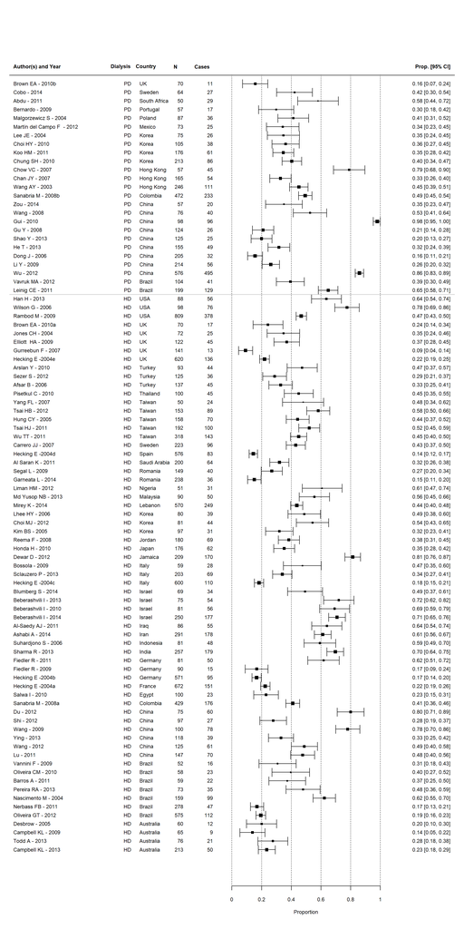

[Back to top]

## 3.2 Dialysis studies ordered according to study size

Observation: The size of the study does not seem to allow conclusions about the PEW prevalence (p = 0.124; p = 0.136 for grouped study size). But note the increasing confidence limits as study size decreases (as expected).

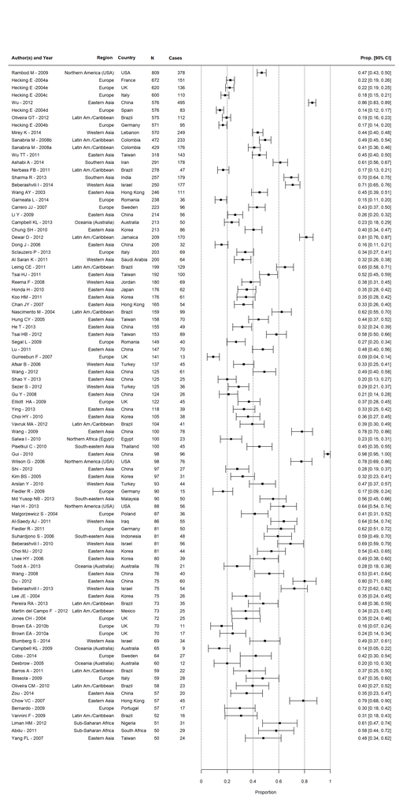

[Back to top]

## 3.3 Dialysis studies ordered according to PEW determination

Observation: The applied method for PEW determination does not seem to allow conclusions about the PEW prevalence reported in a study (p = 0.225 when adjusting for region; p = 0.028 unadjusted indicates that PEW determination is confounded with region).

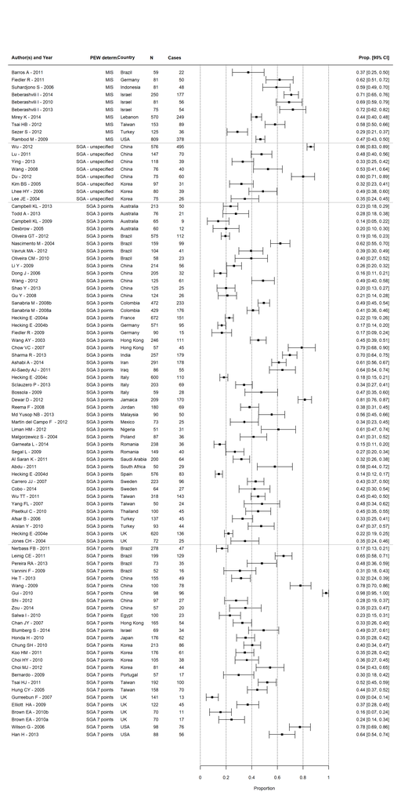

[Back to top]

## 3.4 Dialysis studies ordered according to GNI

Observation: The GNI of the country where the study is reported from does not seem to allow conclusions about the PEW prevalence reported in a study (p = 0.449).

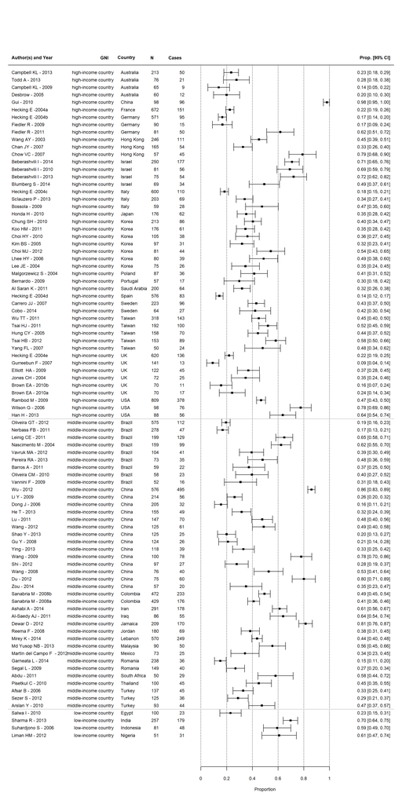

[Back to top]

## 3.5 Dialysis studies ordered according to Quality Index

Observation: The quality of a study as determined by our quality index (see S2 above) does not seem to allow conclusions about the PEW prevalence reported in a study (p = 0.872; p = 0.926 for dichotomous quality index above/below 5/8).

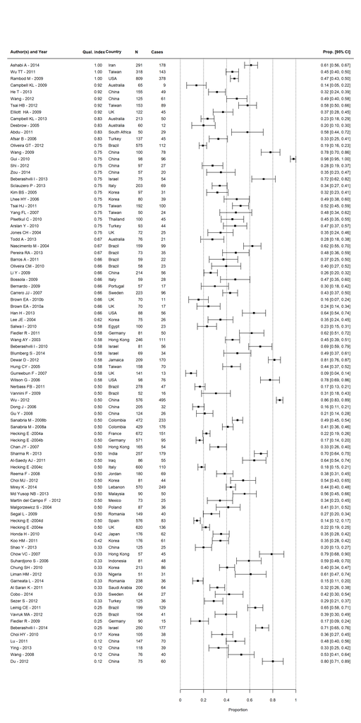

[Back to top]

## 3.6 Dialysis studies ordered according to publication year

Observation: The year of publication does not seem to allow conclusions about the PEW prevalence reported in a study (p = 0.294 when adjusting for region; p = 0.026 unadjusted indicates that publication year is confounded with region).

We conclude that it is not the case that more recent studies start to agree more on PEW prevalence.

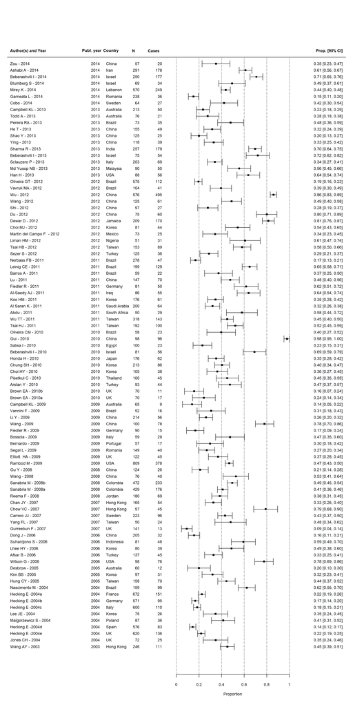

[Back to top]

## 3.7 Dialysis studies ordered according to PEW prevalence

Observation: This demonstrates where the name “catterpilar plot” for these plots comes from. When ordered by prevalence, the aligned individual estimates visually resemble a hairy caterpillar.

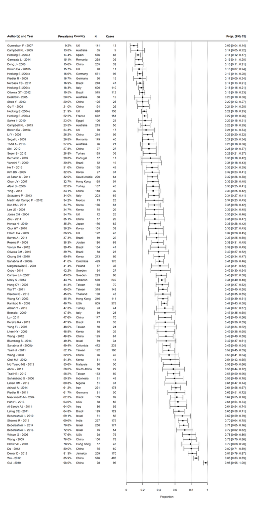

[Back to top]

# 4 Synthesis of results: Fixed-effects model/meta regression for dialysis studies

**For comparison**: A simple random-effects model renders the following statistics (test for heterogeneity is highly significant, p < .0001 ).

| Statistic | Explanation | Point estimate | 95% Conf. Int. |
| --- | --- | --- | --- |
| $\tau^2$ | Estimated amount of residual heterogeneity | 0.037 | (0.027, 0.050) |
| $I^2 (\%)$ | Ratio of residual heterogeneity and unaccounted variability | 97.36 | (96.47, 98.05) |

**Meta-regression**: The moderator Region in this model is highly significant ( p < .0001 ) and “explains” about 23% of the observed heterogeneity in the data (R<sup>2</sup> = 23.27%). The test for residual heterogeneity is highly significant, p < .0001 ).

| Statistic | Explanation | Point estimate | 95% Conf. Int. |
| --- | --- | --- | --- |
| $\tau^2$ | Estimated amount of residual heterogeneity | 0.028 | (0.020, 0.039) |
| $I^2 (\%)$ | Ratio of residual heterogeneity and unaccounted variability | 96.46 | (95.18, 97.44) |

Since this is a mixed-effects model with Region as moderator, there is no longer a single overall effect attributed to the studies. Instead, one such level can be derived for each Region (level of moderator).

**Table**: Estimates for the average PEW prevalence in the respective regions (model based). *Due to the remaining high residual heterogeneity these should be taken as broadly indicative at best.* Each study’s individual random sampling error would be in addition to this source of uncertainty.

| Region | PEW-prevalence | C.I. lower bound (95%) | C.I. upper bound (95%) |
| --- | --- | --- | --- |
| Northern America (USA) | 0.62 | 0.43 | 0.82 |
| Latin Am./Caribbean | 0.44 | 0.34 | 0.53 |
| Europe | 0.28 | 0.21 | 0.36 |
| Northern Africa (Egypt) | 0.23 | 0.00 | 0.57 |
| Sub-Saharan Africa | 0.59 | 0.34 | 0.85 |
| Western Asia | 0.50 | 0.39 | 0.60 |
| Eastern Asia | 0.46 | 0.40 | 0.52 |
| South-eastern Asia | 0.53 | 0.33 | 0.73 |
| Southern Asia | 0.65 | 0.42 | 0.89 |
| Oceania (Australia) | 0.21 | 0.04 | 0.38 |

The (model based) average PEW prevalences for each region are shown by the gray polygons in the forest plot. Their respective width corresponds to the confidence interval limits for the fitted values (model-based “expected” value based on the Region where the study was conducted; each study’s individual random sampling error would be in addition to this source of uncertainty).

[Back to top]

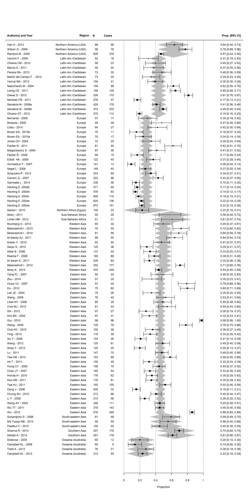

The funnel plot does not suggest that publications would be systematically missing due to publication or other reporting bias: The figure shows each study’s residual value (estimated - overall PEW proportion) against the respective estimates’ standard error (largely determined by the study size). The latter’s scale is inverted with highest precision (largest study sizes) at the top. In the absence of publication and other reporting biases, one would expect that the dots scatter symmetrically around the vertical line at zero residual value. A few studies with low precision have high positive residual values (dots on the bottom to the right) which are not “balanced” by comparatively negative ones. Irrespective of this minor observation, we find that the bulk of the observations is rather balanced and therefore are not concerned with respect to publication or reporting biases.

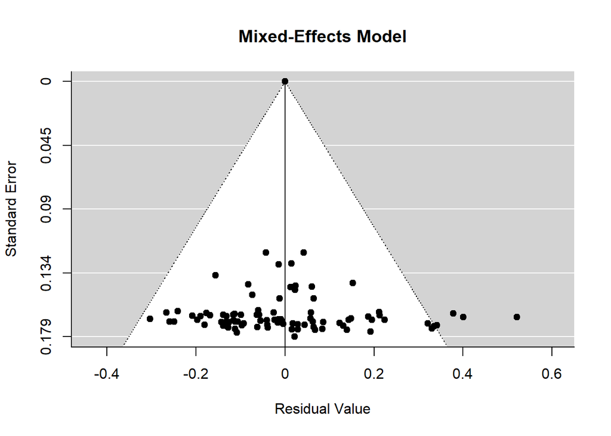

[Back to top]

# 5 Supplemental tables (dialysis studies)

For the hierarchy of geographcial regions and subregions we follow the United Nation’s association of countries with geographical regions and refer to countries by their short forms which may or may not coincide with the name used by that country in official documents. See the [United Nations M49 Standard “Standard Country or Area Codes for Statistical Use”](https://unstats.un.org/unsd/methodology/m49/) .

[Back to top]

## 5.1 Contributing dialysis studies by regions as used for this study

| Region (as used in this study) | Countries | No. of studies | Combined Cases | Combined N | Raw % Cases |
| --- | --- | --- | --- | --- | --- |
| Eastern Asia | China, Hong Kong, Japan, Korea, Taiwan | 31 | 2197 | 4634 | 47.4 |
| Europe | France, Germany, Italy, Poland, Portugal, Romania, Spain, Sweden, UK | 20 | 1100 | 4765 | 23.1 |
| Latin Am./Caribbean | Brazil, Colombia, Jamaica, Mexico | 13 | 1128 | 2740 | 41.2 |
| Northern Africa (Egypt) | Egypt | 1 | 23 | 100 | 23.0 |
| Northern America (USA) | USA | 3 | 510 | 995 | 51.3 |
| Oceania (Australia) | Australia | 4 | 92 | 414 | 22.2 |
| South-eastern Asia | Indonesia, Malaysia, Thailand | 3 | 143 | 271 | 52.8 |
| Southern Asia | India, Iran | 2 | 357 | 548 | 65.1 |
| Sub-Saharan Africa | Nigeria, South Africa | 2 | 60 | 101 | 59.4 |
| Western Asia | Iraq, Israel, Jordan, Lebanon, Saudi Arabia, Turkey | 11 | 883 | 1866 | 47.3 |
| Total |  | 90 | 6493 | 16434 | 39.5 |

[Back to top]

## 5.2 Contributing dialysis studies by geographic region

| Geographic Region | Countries | No. of studies | Combined Cases | Combined N | Raw % Cases |
| --- | --- | --- | --- | --- | --- |
| Africa | Egypt, Nigeria, South Africa | 3 | 83 | 201 | 41.3 |
| Americas | Brazil, Colombia, Jamaica, Mexico, USA | 16 | 1638 | 3735 | 43.9 |
| Asia | China, Hong Kong, India, Indonesia, Iran, Iraq, Israel, Japan, Jordan, Korea, Lebanon, Malaysia, Saudi Arabia, Taiwan, Thailand, Turkey | 47 | 3580 | 7319 | 48.9 |
| Europe | France, Germany, Italy, Poland, Portugal, Romania, Spain, Sweden, UK | 20 | 1100 | 4765 | 23.1 |
| Oceania | Australia | 4 | 92 | 414 | 22.2 |
| Total |  | 90 | 6493 | 16434 | 39.5 |

[Back to top]

## 5.3 Contributing dialysis studies by geographic subregion

| Geographic Subregion | Countries | No. of studies | Combined Cases | Combined N | Raw % Cases |
| --- | --- | --- | --- | --- | --- |
| Australia and New Zealand | Australia | 4 | 92 | 414 | 22.2 |
| Caribbean | Jamaica | 1 | 170 | 209 | 81.3 |
| Central America | Mexico | 1 | 25 | 73 | 34.2 |
| Eastern Asia | China, Hong Kong, Japan, Korea, Taiwan | 31 | 2197 | 4634 | 47.4 |
| Eastern Europe | Poland, Romania | 3 | 112 | 474 | 23.6 |
| Northern Africa | Egypt | 1 | 23 | 100 | 23.0 |
| Northern America | USA | 3 | 510 | 995 | 51.3 |
| Northern Europe | Sweden, UK | 8 | 370 | 1382 | 26.8 |
| South-eastern Asia | Indonesia, Malaysia, Thailand | 3 | 143 | 271 | 52.8 |
| South America | Brazil, Colombia | 11 | 933 | 2458 | 38.0 |
| Southern Africa | South Africa | 1 | 29 | 50 | 58.0 |
| Southern Asia | India, Iran | 2 | 357 | 548 | 65.1 |
| Southern Europe | Italy, Portugal, Spain | 5 | 307 | 1495 | 20.5 |
| Western Africa | Nigeria | 1 | 31 | 51 | 60.8 |
| Western Asia | Iraq, Israel, Jordan, Lebanon, Saudi Arabia, Turkey | 11 | 883 | 1866 | 47.3 |
| Western Europe | France, Germany | 4 | 311 | 1414 | 22.0 |
| Total |  | 90 | 6493 | 16434 | 39.5 |

[Back to top]

## 5.4 Contributing dialysis studies by GNI group

| GNI Group | Countries | No. of studies | Combined Cases | Combined N | Raw % Cases |
| --- | --- | --- | --- | --- | --- |
| high-income country | Australia, China, France, Germany, Hong Kong, Israel, Italy, Japan, Korea, Poland, Portugal, Saudi Arabia, Spain, Sweden, Taiwan, UK, USA | 47 | 3130 | 8902 | 35.2 |
| low-income country | Egypt, India, Indonesia, Nigeria | 4 | 281 | 489 | 57.5 |
| middle-income country | Brazil, China, Colombia, Iran, Iraq, Jamaica, Jordan, Lebanon, Malaysia, Mexico, Romania, South Africa, Thailand, Turkey | 39 | 3082 | 7043 | 43.8 |
| Total |  | 90 | 6493 | 16434 | 39.5 |

[Back to top]

## 5.5 Contributing dialysis studies by country

| Country | No. of studies | Combined Cases | Combined N | Raw % Cases |
| --- | --- | --- | --- | --- |
| Australia | 4 | 92 | 414 | 22.2 |
| Brazil | 9 | 524 | 1557 | 33.7 |
| China | 15 | 1174 | 2292 | 51.2 |
| Colombia | 2 | 409 | 901 | 45.4 |
| Egypt | 1 | 23 | 100 | 23.0 |
| France | 1 | 151 | 672 | 22.5 |
| Germany | 3 | 160 | 742 | 21.6 |
| Hong Kong | 3 | 210 | 468 | 44.9 |
| India | 1 | 179 | 257 | 69.6 |
| Indonesia | 1 | 48 | 81 | 59.3 |
| Iran | 1 | 178 | 291 | 61.2 |
| Iraq | 1 | 55 | 86 | 64.0 |
| Israel | 4 | 321 | 475 | 67.6 |
| Italy | 3 | 207 | 862 | 24.0 |
| Jamaica | 1 | 170 | 209 | 81.3 |
| Japan | 1 | 62 | 176 | 35.2 |
| Jordan | 1 | 69 | 180 | 38.3 |
| Korea | 7 | 325 | 827 | 39.3 |
| Lebanon | 1 | 249 | 570 | 43.7 |
| Malaysia | 1 | 50 | 90 | 55.6 |
| Mexico | 1 | 25 | 73 | 34.2 |
| Nigeria | 1 | 31 | 51 | 60.8 |
| Poland | 1 | 36 | 87 | 41.4 |
| Portugal | 1 | 17 | 57 | 29.8 |
| Romania | 2 | 76 | 387 | 19.6 |
| Saudi Arabia | 1 | 64 | 200 | 32.0 |
| South Africa | 1 | 29 | 50 | 58.0 |
| Spain | 1 | 83 | 576 | 14.4 |
| Sweden | 2 | 123 | 287 | 42.9 |
| Taiwan | 5 | 426 | 871 | 48.9 |
| Thailand | 1 | 45 | 100 | 45.0 |
| Turkey | 3 | 125 | 355 | 35.2 |
| UK | 6 | 247 | 1095 | 22.6 |
| USA | 3 | 510 | 995 | 51.3 |
| Total | 90 | 6493 | 16434 | 39.5 |

[Back to top]

# Software/R packages used for this document

[Back to top]

The following software/R-packages have been very helpful in compiling this document and are gratefully acknowledged.

| Package | Reference |
| --- | --- |
| R | R Core Team (2018). R: A language and environment for statistical computing. R Foundation for Statistical Computing, Vienna, Austria. URL https://www.R-project.org/. |
| R Studio | RStudio Team (2016). RStudio: Integrated Development for R. RStudio, Inc., Boston, MA URL http://www.rstudio.com/. |
| knitr | Yihui Xie (2018). knitr: A General-Purpose Package for Dynamic Report Generation in R. R package version 1.20., Yihui Xie (2015) Dynamic Documents with R and knitr. 2nd edition. Chapman and Hall/CRC. … |
| rmarkdown | JJ Allaire, Yihui Xie, Jonathan McPherson, Javier Luraschi, Kevin Ushey, Aron Atkins, Hadley Wickham, Joe Cheng and Winston Chang (2018). rmarkdown: Dynamic Documents for R. R package version 1.10. ht… |
| metafor | Viechtbauer, W. (2010). Conducting meta-analyses in R with the metafor package. Journal of Statistical Software, 36(3), 1-48. URL: http://www.jstatsoft.org/v36/i03/ |

[Back to top]

End of document